# Course: Foundations of Machine Learning Frameworks

## Practical Lab 2: Multivariate Linear Regression, Non-Parametric Models and Cross-Validation

### *Name: Neha Yadav*

### Due date: 13th Oct,24

#### Import Necessary Libraries

- NumPy and Pandas: For example used in calculations involving numbers or computations in large data sets etc.
- Matplotlib and Seaborn: Presumably, there are libraries for visualizations of data.
- Scikit-learn: Includes facilities to load datasets, train a model and perform assessment.

```python
# Import necessary libraries
import numpy as np
import pandas as pd
import matplotlib.pyplot as plt
import seaborn as sns
from sklearn import datasets
from sklearn.model_selection import train_test_split
from sklearn.preprocessing import PolynomialFeatures
from sklearn.linear_model import LinearRegression
from sklearn.tree import DecisionTreeRegressor
from sklearn.neighbors import KNeighborsRegressor
from sklearn.metrics import mean_absolute_error, mean_absolute_percentage_error, r2_score

# Set the style for seaborn
sns.set(style="whitegrid")
```

#### Part 1: Data Acquisition and Exploration

#### 1. Load the diabetes dataset

```python
diabetes = datasets.load_diabetes(as_frame=True)
```

#### 2. Frame the Problem

- X has the input data of the features that have been developed, while y has the output data in terms of disease progression. We print the number of samples just for us to confirm that they have been loaded successfully.

```python
# The target variable is 'target', which represents disease progression after one year.
X = diabetes.data
y = diabetes.target
print("Dataset loaded. Number of samples:", len(y))
```

```
Dataset loaded. Number of samples: 442
```

### 3. Exploratory Data Analysis (EDA)

## Descriptive Statistics

- This generates a text printed description of the dataset in addition to feature descriptions.

```python
# Descriptive statistics
print(diabetes.DESCR)
```

```
.. _diabetes_dataset:

Diabetes dataset
----------------

Ten baseline variables, age, sex, body mass index, average blood
pressure, and six blood serum measurements were obtained for each of n =
442 diabetes patients, as well as the response of interest, a
quantitative measure of disease progression one year after baseline.

**Data Set Characteristics:**

:Number of Instances: 442

:Number of Attributes: First 10 columns are numeric predictive values

:Target: Column 11 is a quantitative measure of disease progression one year after baseline

:Attribute Information:
    - age     age in years
    - sex
    - bmi     body mass index
    - bp      average blood pressure
    - s1      tc, total serum cholesterol
    - s2      ldl, low-density lipoproteins
    - s3      hdl, high-density lipoproteins
    - s4      tch, total cholesterol / HDL
    - s5      ltg, possibly log of serum triglycerides level
    - s6      glu, blood sugar level

Note: Each of these 10 feature variables have been mean centered and scaled by the standard deviation times the square root of `n_samples` (i.e. the sum of squares of each column totals 1).

Source URL:
https://www4.stat.ncsu.edu/~boos/var.select/diabetes.html

For more information see:
Bradley Efron, Trevor Hastie, Iain Johnstone and Robert Tibshirani (2004) "Least Angle Regression," Annals of Statistics (with discussion), 407-499.
(https://web.stanford.edu/~hastie/Papers/LARS/LeastAngle_2002.pdf)
```

## Statistics of the Data

- It gives a summary of the parameter pertaining to the features within the dataset including the mean, SD, min, max values, etc…

```python
# Statistics of the data
data_description = X.describe()
print(data_description)
```

```
                age           sex           bmi            bp            s1  \
count  4.420000e+02  4.420000e+02  4.420000e+02  4.420000e+02  4.420000e+02
mean  -2.511817e-19  1.230790e-17 -2.245564e-16 -4.797570e-17 -1.381499e-17
std    4.761905e-02  4.761905e-02  4.761905e-02  4.761905e-02  4.761905e-02
min   -1.072256e-01 -4.464164e-02 -9.027530e-02 -1.123988e-01 -1.267807e-01
25%   -3.729927e-02 -4.464164e-02 -3.422907e-02 -3.665608e-02 -3.424784e-02
50%    5.383060e-03 -4.464164e-02 -7.283766e-03 -5.670422e-03 -4.320866e-03
75%    3.807591e-02  5.068012e-02  3.124802e-02  3.564379e-02  2.835801e-02
max    1.107267e-01  5.068012e-02  1.705552e-01  1.320436e-01  1.539137e-01

                 s2            s3            s4            s5            s6
count  4.420000e+02  4.420000e+02  4.420000e+02  4.420000e+02  4.420000e+02
mean   3.918434e-17 -5.777179e-18 -9.042540e-18  9.293722e-17  1.130318e-17
std    4.761905e-02  4.761905e-02  4.761905e-02  4.761905e-02  4.761905e-02
min   -1.156131e-01 -1.023071e-01 -7.639450e-02 -1.260971e-01 -1.377672e-01
25%   -3.035840e-02 -3.511716e-02 -3.949338e-02 -3.324559e-02 -3.317903e-02
50%   -3.819065e-03 -6.584468e-03 -2.592262e-03 -1.947171e-03 -1.077698e-03
75%    2.984439e-02  2.931150e-02  3.430886e-02  3.243232e-02  2.791705e-02
max    1.987880e-01  1.811791e-01  1.852344e-01  1.335973e-01  1.356118e-01
```

## Scatter Plots and Histograms

- First of all, we allocate a plotting area of size 15 inches by 5 inches.
- The scatter plot to compare the BMI and the disease progression follows below.
- This enables us generate a scatter plot of BMI against the disease progression in order to ascertain the patterns that exists between them.

## Target Variable Frequency Distribution

- This displays the target variable using a histogram with Kernel Density Estimate (KDE) line plot superimposed on the histogram.

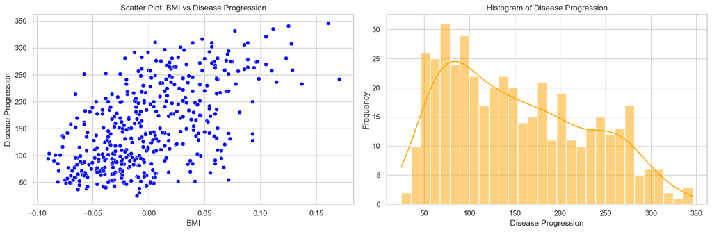

```python
# Scatter plots and histograms
plt.figure(figsize=(15, 5))

# Scatter plot for BMI vs Disease Progression
plt.subplot(1, 2, 1)
sns.scatterplot(x=X['bmi'], y=y, color='blue')
plt.title('Scatter Plot: BMI vs Disease Progression')
plt.xlabel('BMI')
plt.ylabel('Disease Progression')

# Histogram of the target variable
plt.subplot(1, 2, 2)
sns.histplot(y, bins=30, kde=True, color='orange')
plt.title('Histogram of Disease Progression')
plt.xlabel('Disease Progression')
plt.ylabel('Frequency')

plt.tight_layout()
plt.show()
```

## Correlation Matrix

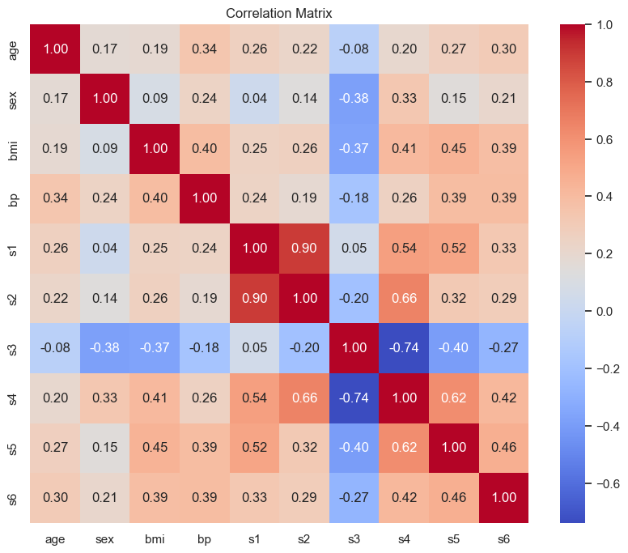

```python
# Correlation matrix
plt.figure(figsize=(10, 8))
corr_matrix = X.corr()
sns.heatmap(corr_matrix, annot=True, fmt=".2f", cmap='coolwarm', square=True)
plt.title('Correlation Matrix')
plt.show()
```

#### Insights

- From the scatter plot, we can see that there may be a positive correlation between BMI and disease progression.
- The histogram indicates that the disease progression is right-skewed.

#### 4. Data Cleaning (if needed)

- This ensures deficit of values in the dataset is taken note of. As of this data set, there are no missing values and therefore no data cleaning is necessary.

```python
# Check for missing values
print(X.isnull().sum())

# No missing values found, so no cleaning needed.
```

```
age    0
sex    0
bmi    0
bp     0
s1     0
s2     0
s3     0
s4     0
s5     0
s6     0
dtype: int64
```

#### 5. Split the dataset into train (75%), validation (10%), and test (15%)

- The dataset is divided into 75% training data, 10% validation data and 15% test data. It means that we are able to train the model, adjust it, and lastly test the model on the unseen data.

```python
X_train, X_temp, y_train, y_temp = train_test_split(X, y, test_size=0.25, random_state=42)
X_val, X_test, y_val, y_test = train_test_split(X_temp, y_temp, test_size=0.6, random_state=42)

print("Training set size:", X_train.shape[0])
print("Validation set size:", X_val.shape[0])
print("Test set size:", X_test.shape[0])
```

```
Training set size: 331
Validation set size: 44
Test set size: 67
```

#### Part 2: Model Building and Evaluation

#### 6. Univariate polynomial regression on the BMI feature

#### Training Polynomial Regression Models

- For univariate models, we pay special attention to the BMI feature, taking it from training, validation, and test sets.

#### Storing Results

- A list to keep the result of the evaluation for different polynomials of some degree.

#### Loop through Polynomial Degrees

- We use the BMI data and employ polynomial functions of each degree from 0 to 5 to fit our training data.

```python
bmi_train = X_train[['bmi']]
bmi_val = X_val[['bmi']]
bmi_test = X_test[['bmi']]

# Store results
results = []

# Train polynomial regression models from degree 0 to 5
for degree in range(6):
    # Create polynomial features
    poly = PolynomialFeatures(degree=degree)
    X_poly_train = poly.fit_transform(bmi_train)
    X_poly_val = poly.transform(bmi_val)

    # Fit the model
    model = LinearRegression()
    model.fit(X_poly_train, y_train)

    # Predictions
    y_train_pred = model.predict(X_poly_train)
    y_val_pred = model.predict(X_poly_val)

    # Evaluate the model
    r2_train = r2_score(y_train, y_train_pred)
    mae_train = mean_absolute_error(y_train, y_train_pred)
    mape_train = mean_absolute_percentage_error(y_train, y_train_pred)

    r2_val = r2_score(y_val, y_val_pred)
    mae_val = mean_absolute_error(y_val, y_val_pred)
    mape_val = mean_absolute_percentage_error(y_val, y_val_pred)

    # Store results
    results.append((degree, r2_train, mae_train, mape_train, r2_val, mae_val, mape_val))
```

#### 7. Compare the models using the training and validation data

#### Model Training and Evaluation

- We fit a linear regression model to the polynomial features to the training dataset and perform the same to the validation set.

#### Calculate Metrics

- Using training and validation sets, we calculate R-squared and the Mean Absolute Error (MAE), and the Mean Absolute Percentage Error (MAPE).

#### Store Results

- For further analysis, we add its results to our results list after appending it.

#### Results DataFrame

- In order to make the findings more readable, we create a DataFrame and then print it.

```python
# Create a DataFrame for results
results_df = pd.DataFrame(results, columns=['Degree', 'R² Train', 'MAE Train', 'MAPE Train', 'R² Val', 'MAE Val', 'MAPE Val'])

# Display the results in a table format with borders
styled_results_df = results_df.style.set_table_attributes('style="border-collapse: collapse; width: 100%;"') \
    .set_table_styles([{'selector': 'th', 'props': [('border', '1px solid black'), ('padding', '8px'), ('text-align', 'center')]},
                       {'selector': 'td', 'props': [('border', '1px solid black'), ('padding', '8px'), ('text-align', 'center')]}])

# Display the styled DataFrame
display(styled_results_df)
```

|  | Degree | R² Train | MAE Train | MAPE Train | R² Val | MAE Val | MAPE Val |
| --- | --- | --- | --- | --- | --- | --- | --- |
| 0 | 0 | 0.000000 | 66.201641 | 0.628267 | -0.106957 | 66.057059 | 0.712639 |
| 1 | 1 | 0.349672 | 52.287739 | 0.483629 | 0.331264 | 47.208472 | 0.470600 |
| 2 | 2 | 0.350764 | 52.207314 | 0.482985 | 0.331631 | 47.213700 | 0.472397 |
| 3 | 3 | 0.350774 | 52.198968 | 0.482807 | 0.331638 | 47.185414 | 0.472227 |
| 4 | 4 | 0.353014 | 52.092653 | 0.480533 | 0.340758 | 46.090118 | 0.460503 |
| 5 | 5 | 0.354100 | 52.059191 | 0.480040 | 0.349881 | 45.462121 | 0.451753 |

#### 8. Identify the best model based on validation results

- We equate the model with the highest R-squared on the validation partition to the best fitting model.

```python
best_model_idx = results_df['R² Val'].idxmax()  # Get the index of the best model
best_model = results_df.iloc[best_model_idx]  # Extract the best model's results

# Create a DataFrame for the best model for display
best_model_df = pd.DataFrame(best_model).transpose()  # Transpose for better formatting

# Display the best model in a table format with borders
styled_best_model_df = best_model_df.style.set_table_attributes('style="border-collapse: collapse; width: 100%;"') \
    .set_table_styles([{'selector': 'th', 'props': [('border', '1px solid black'), ('padding', '8px'), ('text-align', 'center')]},
                       {'selector': 'td', 'props': [('border', '1px solid black'), ('padding', '8px'), ('text-align', 'center')]}])

# Display the styled best model DataFrame
print("** Best Model Based on Validation Results **")
display(styled_best_model_df)
```

```
** Best Model Based on Validation Results **
```

|  | Degree | R² Train | MAE Train | MAPE Train | R² Val | MAE Val | MAPE Val |
| --- | --- | --- | --- | --- | --- | --- | --- |
| 5 | 5.000000 | 0.354100 | 52.059191 | 0.480040 | 0.349881 | 45.462121 | 0.451753 |

#### Step 9: Run the chosen model on the test set

- We also check the accuracy of the best model using the same metrics on the test set so as to make sure that the model has good reliable accuracy.

```python
degree = int(best_model['Degree'])  # Ensure degree is an integer
poly = PolynomialFeatures(degree=degree)
X_poly_train = poly.fit_transform(bmi_train)
X_poly_test = poly.transform(bmi_test)

chosen_model = LinearRegression()
chosen_model.fit(X_poly_train, y_train)
y_test_pred = chosen_model.predict(X_poly_test)

# Calculate metrics
r2_test = r2_score(y_test, y_test_pred)
mae_test = mean_absolute_error(y_test, y_test_pred)
mape_test = mean_absolute_percentage_error(y_test, y_test_pred)

print(f"Test Set Results - R^2: {r2_test:.2f}, MAE: {mae_test:.2f}, MAPE: {mape_test:.2f}")
```

```
Test Set Results - R^2: 0.27, MAE: 51.75, MAPE: 0.43
```

#### Step 10: Plot the results

- This means that we plot the test data against the responses given by the model so that we can see just how the model performs when fitted on the unseen test data.

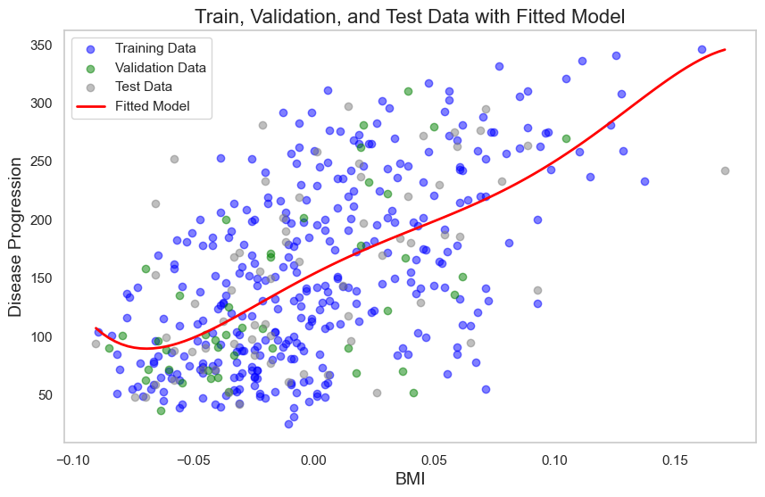

```python
# Prepare polynomial features for plotting the fitted model
bmi_range = np.linspace(X['bmi'].min(), X['bmi'].max(), 100).reshape(-1, 1)
X_poly_range = poly.transform(bmi_range)
y_fit = chosen_model.predict(X_poly_range)

# Plotting
plt.figure(figsize=(10, 6))

# Plot training data
plt.scatter(bmi_train, y_train, color='blue', label='Training Data', alpha=0.5)
# Plot validation data
plt.scatter(bmi_val, y_val, color='green', label='Validation Data', alpha=0.5)
# Plot test data
plt.scatter(bmi_test, y_test, color='gray', label='Test Data', alpha=0.5)
# Plot the fitted polynomial curve
plt.plot(bmi_range, y_fit, color='red', label='Fitted Model', linewidth=2)

# Add titles and labels
plt.title('Train, Validation, and Test Data with Fitted Model', fontsize=16)
plt.xlabel('BMI', fontsize=14)
plt.ylabel('Disease Progression', fontsize=14)
plt.legend()
plt.grid()
plt.show()
```

#### 11. Write down the equation of the best model

- This along with builds and outputs the mathematical equation of the fitted model that best fits the data from the coefficients deduced during training.

```python
# Coefficients of the best model
coeffs = chosen_model.coef_
intercept = chosen_model.intercept_
print(f"Best model equation: y = {intercept:.2f} + " + " + ".join([f"{coeff:.2f}*x^{i}" for i, coeff in enumerate(coeffs) if i > 0]))
```

```
Best model equation: y = 153.65 + 1059.89*x^1 + -3824.15*x^2 + -16770.23*x^3 + 753722.52*x^4 + -2993716.57*x^5
```

#### 12. Calculate expected diabetes progression for a BMI value

- we estimate the time to the next disease state for the specified BMI value, which shows the application of the model.

```python
bmi_value = 30  # Example BMI value
expected_progression = chosen_model.predict(poly.fit_transform([[bmi_value]]))
print(f"Expected diabetes progression for BMI = {bmi_value}: {expected_progression[0]:.2f}")
```

```
Expected diabetes progression for BMI = 30: -72137253699190.52
```

#### Step 13: Count trainable parameters and explain

- This measures the many features that the model has, that is, the number of parameters in the model.

```python
# Get the feature names for the chosen model
feature_names = poly.get_feature_names_out(input_features=['bmi'])  # Get feature names for polynomial features
num_params = len(chosen_model.coef_)  # Count number of trainable parameters
print(f"Number of trainable parameters: {num_params}")

# Display the feature names and their corresponding coefficients
params_df = pd.DataFrame({
    'Feature': feature_names,
    'Coefficient': chosen_model.coef_
})

# Display the feature names and their corresponding coefficients in a styled table format
styled_params_df = params_df.style.set_table_attributes('style="border-collapse: collapse; width: 100%;"') \
    .set_table_styles([{'selector': 'th', 'props': [('border', '1px solid black'), ('padding', '8px'), ('text-align', 'center')]},
                       {'selector': 'td', 'props': [('border', '1px solid black'), ('padding', '8px'), ('text-align', 'center')]}])

# Display the styled DataFrame
print("** Trainable Parameters and Coefficients **")
display(styled_params_df)

# Explanation of the parameters
print("\nExplanation of Trainable Parameters:")
print(f"The model has {num_params} trainable parameters, which include the coefficients for each polynomial term derived from the BMI feature. "
      f"This includes the intercept term and the coefficients for each degree of the polynomial up to the chosen degree.")
```

```
Number of trainable parameters: 6
** Trainable Parameters and Coefficients **
```

|  | Feature | Coefficient |
| --- | --- | --- |
| 0 | 1 | 0.000000 |
| 1 | bmi | 1059.893193 |
| 2 | bmi^2 | -3824.145934 |
| 3 | bmi^3 | -16770.234632 |
| 4 | bmi^4 | 753722.516105 |
| 5 | bmi^5 | -2993716.573297 |

```
Explanation of Trainable Parameters:
The model has 6 trainable parameters, which include the coefficients for each polynomial term derived from the BMI feature. This includes the intercept term and the coefficients for each degree of the polynomial up to the chosen degree.
```